# Intel Student Developer Club, RCOEM

## Machine Learning Bootcamp, 2022

## Day - 2 : Supervised Learning 👋

### Regularization :

#### Generalization :

→ In supervised learning, we want to build a model on the training data and then be able to make accurate predictions on new, unseen data that has the same characteristics as the training set that we used. If a model is able to make accurate predictions on unseen data, we say it is able to *generalize* from the training set to the test set. We want to build a model that is able to generalize as accurately as possible.

→ Usually we build a model in such a way that it can make accurate predictions on the training set. If the training and test sets have enough in common, we expect the model to also be accurate on the test set. However, there are some cases where this can go wrong. For example, if we allow ourselves to build very complex models, we can always be as accurate as we like on the training set.

#### Overfitting and Underfitting :

→ Building a model that is too complex for the amount of info we have is called *Overfitting* the model. *Overfitting* occurs when you fit a model too closely to the particularities of the training set and obtain the a model that works too well on the training set but is not able to generalize on new data.

→ On the other hand, if our model is very simple then we might not be able to catch all the aspects and variability in the data, and the model will perform badly even on the training data, this is called *Underfitting*

[figure not shown]

#### Lets now see a live example of Over and Underfitting

[figure not shown]

#### Over-Fitting

[figure not shown]

#### Under-Fitting

[figure not shown]

#### Bias and Variance

The inability of a machine learning model (for ex. Linear Regression) to capture the true relationship between data points is called *Bias*.

The difference in fits between the datasets of a model is called *Variance*.

**Underfitting** : High Bias, Low Variance ; This does not explore all the data points in the dataset  
**Overfitting** : Low Bias, High Variance ; This fits great on training data but might not fit on testing data

[figure not shown]

### Introduction to Linear Regression :

The general formula for a linear regression model is as follows :-

$f(x) \equiv y = a + bx$

ie, for a value of $x$ on the $x-axis$ we will get a corresponding value of $y$, which will be our outcome or prediction.

[figure not shown]

**Residual Error** :  
$\equiv f(x_{obs}) - y_{obs}$  
$\equiv a + bx_{obs} - y_{obs}$  
$J(a,b) = 1/2m \sum[((a + bx_{obs}) - y_{obs})]^2$ → Here, we want to minimize the mean squared error.

### KNN vs. Linear Regression :

#### A. Linear Regression :

- Fitting involves minimizing cost function, making it slower.
- Model has few parameters [memory efficient]
- Prediction involves calculation, ie, just putting $x$ data in function to get value.

#### B. KNN :

- Fitting involves storing training data, ie, storing min value (fast).
- Model has many parameters [memory efficient].
- Prediction involves finding closest neighbors, $\therefore$ slow.

### Let us now create our very own Linear Regression Model

```python
# Step 1 : Import the necessary libraries and datasets

import numpy as np
import matplotlib.pyplot as plt
import seaborn as sns
import pandas as pd

from sklearn.datasets import load_boston
from sklearn.linear_model import LinearRegression
from sklearn.model_selection import train_test_split
```

### First We Will See a Simple Dataset

```python
canada_df = pd.read_csv('../Assets/canada_per_capita_income.csv')
canada_df.head()
```

|  | year | per capita income (US$) |
| --- | --- | --- |
| 0 | 1970 | 3399.299037 |
| 1 | 1971 | 3768.297935 |
| 2 | 1972 | 4251.175484 |
| 3 | 1973 | 4804.463248 |
| 4 | 1974 | 5576.514583 |

```python
canada_df.tail()
```

|  | year | per capita income (US$) |
| --- | --- | --- |
| 42 | 2012 | 42665.25597 |
| 43 | 2013 | 42676.46837 |
| 44 | 2014 | 41039.89360 |
| 45 | 2015 | 35175.18898 |
| 46 | 2016 | 34229.19363 |

```python
# Basic statistical values of our dataset can be known by using the describe method

canada_df.describe()
```

|  | year | per capita income (US$) |
| --- | --- | --- |
| count | 47.000000 | 47.000000 |
| mean | 1993.000000 | 18920.137063 |
| std | 13.711309 | 12034.679438 |
| min | 1970.000000 | 3399.299037 |
| 25% | 1981.500000 | 9526.914515 |
| 50% | 1993.000000 | 16426.725480 |
| 75% | 2004.500000 | 27458.601420 |
| max | 2016.000000 | 42676.468370 |

```python
# Step 2: Data visualization using seaborn and matpotlib

sns.set_style('darkgrid')
colors = ['#003f5c', '#2f4b7c', '#665191', '#a05195', '#d45087', '#f95d6a', '#ff7c43','#ffa600']
```

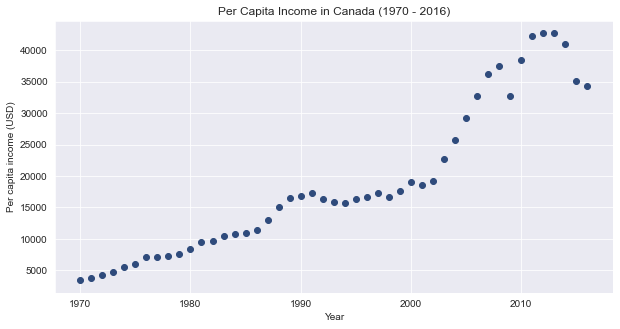

```python
plt.figure(figsize=(10,5))

plt.scatter(canada_df['year'], canada_df['per capita income (US$)'], color=colors[1])

plt.title("Per Capita Income in Canada (1970 - 2016)")
plt.xlabel('Year')
plt.ylabel('Per capita income (USD)')

plt.show()
```

We previously saw the general form of a linear regression line which was :-

$f(x) \equiv y = a + bx$

> Note ☢️: This is for a single feature dataset

where, $a$ is the 'intercept' and $b$ is the 'coefficient'.

```python
incReg = LinearRegression()
incReg.fit(canada_df[['year']], canada_df['per capita income (US$)'])

print(f'Coefficient : {incReg.coef_}\nIntercept : {incReg.intercept_}')
```

```
Coefficient : [828.46507522]
Intercept : -1632210.7578554575
```

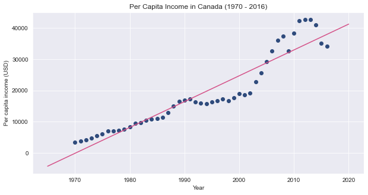

```python
x = np.linspace(1965, 2020, 200)
y = incReg.coef_*x + incReg.intercept_


plt.figure(figsize=(10,5))

plt.scatter(canada_df['year'], canada_df['per capita income (US$)'], color=colors[1])
plt.plot(x, y, color=colors[4])

plt.title("Per Capita Income in Canada (1970 - 2016)")
plt.xlabel('Year')
plt.ylabel('Per capita income (USD)')

plt.show()
```

```python
# Lets try to predict the per capita income for the year 2023.

y_prediction = incReg.predict([[2023]])

print(f"Per capita income for the year 2023 will probably be : {y_prediction[0]:.4f}")
```

```
Per capita income for the year 2023 will probably be : 43774.0893
```

Like this we have trained our first linear regression machine learning model, along with that we have also tested and predicted using some never-before-seen data.

```python
boston = load_boston()

boston
```

[output not shown]

[output cut: 8 more lines]

[output not shown]

- CRIM - per capita crime rate by town
- ZN - proportion of residential land zoned for lots over 25,000 sq.ft.
- INDUS - proportion of non-retail business acres per town.
- CHAS - Charles River dummy variable (1 if tract bounds river; 0 otherwise)
- NOX - nitric oxides concentration (parts per 10 million)
- RM - average number of rooms per dwelling
- DIS - weighted distances to five Boston employment centres
- RAD - index of accessibility to radial highways
- TAX - full-value property-tax rate per $10,000
- PTRATIO - pupil-teacher ratio by town
- B - 1000(Bk - 0.63)^2 where Bk is the proportion of blacks by town
- LSTAT - % lower status of the population
- MEDV - Median value of owner-occupied homes in $1000's

```python
boston.feature_names
```

```
array(['CRIM', 'ZN', 'INDUS', 'CHAS', 'NOX', 'RM', 'AGE', 'DIS', 'RAD',
       'TAX', 'PTRATIO', 'B', 'LSTAT'], dtype='<U7')
```

```python
# Lets look at a sample data point

boston.data[23]
```

```
array([  0.98843,   0.     ,   8.14   ,   0.     ,   0.538  ,   5.813  ,
       100.     ,   4.0952 ,   4.     , 307.     ,  21.     , 394.54   ,
        19.88   ])
```

```python
# Target value of the sample data point

boston.target[23]
```

```
14.5
```

```python
# Lets now try to convert our dataset to a pandas dataframe for better data analysis

boston_df = pd.DataFrame(boston.data, columns=boston.feature_names)
boston_df['Target'] = pd.DataFrame(boston.target)

boston_df.head()
```

|  | CRIM | ZN | INDUS | CHAS | NOX | RM | AGE | DIS | RAD | TAX | PTRATIO | B | LSTAT | Target |
| --- | --- | --- | --- | --- | --- | --- | --- | --- | --- | --- | --- | --- | --- | --- |
| 0 | 0.00632 | 18.0 | 2.31 | 0.0 | 0.538 | 6.575 | 65.2 | 4.0900 | 1.0 | 296.0 | 15.3 | 396.90 | 4.98 | 24.0 |
| 1 | 0.02731 | 0.0 | 7.07 | 0.0 | 0.469 | 6.421 | 78.9 | 4.9671 | 2.0 | 242.0 | 17.8 | 396.90 | 9.14 | 21.6 |
| 2 | 0.02729 | 0.0 | 7.07 | 0.0 | 0.469 | 7.185 | 61.1 | 4.9671 | 2.0 | 242.0 | 17.8 | 392.83 | 4.03 | 34.7 |
| 3 | 0.03237 | 0.0 | 2.18 | 0.0 | 0.458 | 6.998 | 45.8 | 6.0622 | 3.0 | 222.0 | 18.7 | 394.63 | 2.94 | 33.4 |
| 4 | 0.06905 | 0.0 | 2.18 | 0.0 | 0.458 | 7.147 | 54.2 | 6.0622 | 3.0 | 222.0 | 18.7 | 396.90 | 5.33 | 36.2 |

```python
# Basic statistical values of our dataset can be known by using the describe method

boston_df.describe()
```

|  | CRIM | ZN | INDUS | CHAS | NOX | RM | AGE | DIS | RAD | TAX | PTRATIO | B | LSTAT | Target |
| --- | --- | --- | --- | --- | --- | --- | --- | --- | --- | --- | --- | --- | --- | --- |
| count | 506.000000 | 506.000000 | 506.000000 | 506.000000 | 506.000000 | 506.000000 | 506.000000 | 506.000000 | 506.000000 | 506.000000 | 506.000000 | 506.000000 | 506.000000 | 506.000000 |
| mean | 3.613524 | 11.363636 | 11.136779 | 0.069170 | 0.554695 | 6.284634 | 68.574901 | 3.795043 | 9.549407 | 408.237154 | 18.455534 | 356.674032 | 12.653063 | 22.532806 |
| std | 8.601545 | 23.322453 | 6.860353 | 0.253994 | 0.115878 | 0.702617 | 28.148861 | 2.105710 | 8.707259 | 168.537116 | 2.164946 | 91.294864 | 7.141062 | 9.197104 |
| min | 0.006320 | 0.000000 | 0.460000 | 0.000000 | 0.385000 | 3.561000 | 2.900000 | 1.129600 | 1.000000 | 187.000000 | 12.600000 | 0.320000 | 1.730000 | 5.000000 |
| 25% | 0.082045 | 0.000000 | 5.190000 | 0.000000 | 0.449000 | 5.885500 | 45.025000 | 2.100175 | 4.000000 | 279.000000 | 17.400000 | 375.377500 | 6.950000 | 17.025000 |
| 50% | 0.256510 | 0.000000 | 9.690000 | 0.000000 | 0.538000 | 6.208500 | 77.500000 | 3.207450 | 5.000000 | 330.000000 | 19.050000 | 391.440000 | 11.360000 | 21.200000 |
| 75% | 3.677083 | 12.500000 | 18.100000 | 0.000000 | 0.624000 | 6.623500 | 94.075000 | 5.188425 | 24.000000 | 666.000000 | 20.200000 | 396.225000 | 16.955000 | 25.000000 |
| max | 88.976200 | 100.000000 | 27.740000 | 1.000000 | 0.871000 | 8.780000 | 100.000000 | 12.126500 | 24.000000 | 711.000000 | 22.000000 | 396.900000 | 37.970000 | 50.000000 |

```python
# Step 2: Data visualization using seaborn and matpotlib

sns.set_style('darkgrid')
colors = ['#003f5c', '#2f4b7c', '#665191', '#a05195', '#d45087', '#f95d6a', '#ff7c43','#ffa600']
```

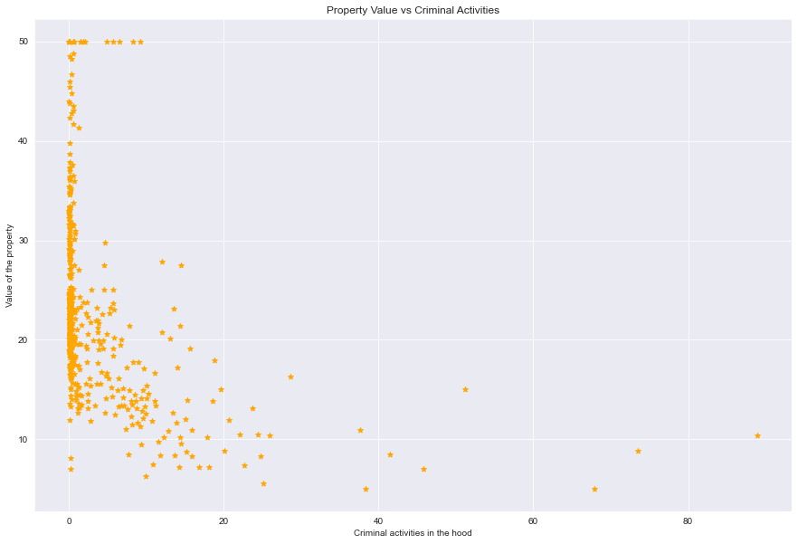

```python
# Let us see the effect of Crime on the property price.

plt.figure(figsize=(15,10))

plt.scatter(boston_df.CRIM, boston_df.Target, color=colors[7], marker='*')

plt.ylabel('Value of the property')
plt.xlabel('Criminal activities in the hood')
plt.title('Property Value vs Criminal Activities')

plt.show()
```

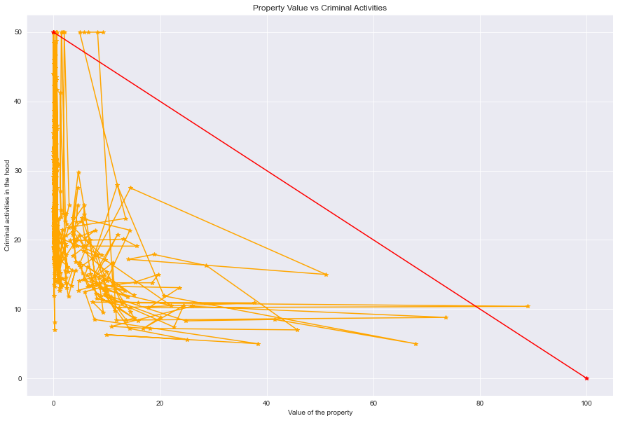

```python
# This type of plots are redundant and inconclusive...

plt.figure(figsize=(15,10))

plt.plot(boston_df.CRIM, boston_df.Target, color=colors[7], marker='*')
plt.plot([0,100], [50, 0], color='red', marker='*')

plt.xlabel('Value of the property')
plt.ylabel('Criminal activities in the hood')
plt.title('Property Value vs Criminal Activities')

plt.show()
```

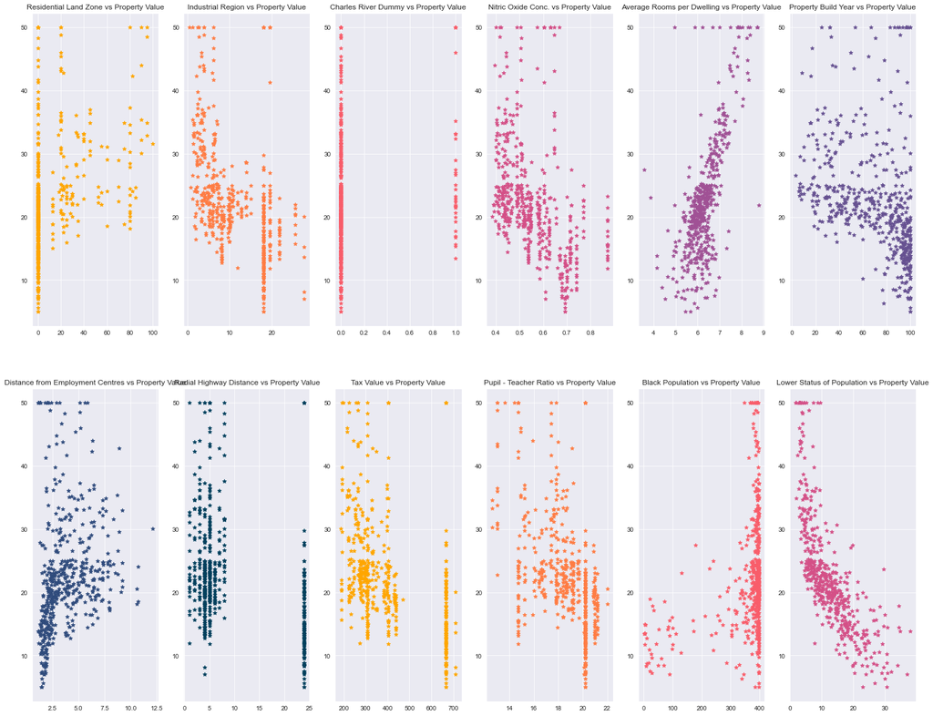

```python
# Likewise lets see how other features change the value of these properties

fig, ax = plt.subplots(ncols=6, nrows=2, figsize=(25,20))

ax[0,0].scatter(boston_df.ZN, boston_df.Target, marker='*', color=colors[7])    # Continuous Data
ax[0,0].set_title('Residential Land Zone vs Property Value')

ax[0,1].scatter(boston_df.INDUS, boston_df.Target, marker='*', color=colors[6]) # Continuous Data
ax[0,1].set_title('Industrial Region vs Property Value')

ax[0,2].scatter(boston_df.CHAS, boston_df.Target, marker='*', color=colors[5])  # Nominal / Categorical Data (1/0)
ax[0,2].set_title('Charles River Dummy vs Property Value')

ax[0,3].scatter(boston_df.NOX, boston_df.Target, marker='*', color=colors[4])   # Continuous Data
ax[0,3].set_title('Nitric Oxide Conc. vs Property Value')

ax[0,4].scatter(boston_df.RM, boston_df.Target, marker='*', color=colors[3])    # Continuous Data
ax[0,4].set_title('Average Rooms per Dwelling vs Property Value')

ax[0,5].scatter(boston_df.AGE, boston_df.Target, marker='*', color=colors[2])   # Continuous Data
ax[0,5].set_title('Property Build Year vs Property Value')

ax[1,0].scatter(boston_df.DIS, boston_df.Target, marker='*', color=colors[1])   # Continuous Data
ax[1,0].set_title('Distance from Employment Centres vs Property Value')

ax[1,1].scatter(boston_df.RAD, boston_df.Target, marker='*', color=colors[0])   # Ordinal Data (index or 0/1/2)
ax[1,1].set_title('Radial Highway Distance vs Property Value')

ax[1,2].scatter(boston_df.TAX, boston_df.Target, marker='*', color=colors[7])   # Continuous Data
ax[1,2].set_title('Tax Value vs Property Value')

ax[1,3].scatter(boston_df.PTRATIO, boston_df.Target, marker='*', color=colors[6])   # Continuous Data
ax[1,3].set_title('Pupil - Teacher Ratio vs Property Value')

ax[1,4].scatter(boston_df.B, boston_df.Target, marker='*', color=colors[5])     # Continuous Data
ax[1,4].set_title('Black Population vs Property Value')

ax[1,5].scatter(boston_df.LSTAT, boston_df.Target, marker='*', color=colors[4]) # Continuous Data
ax[1,5].set_title('Lower Status of Population vs Property Value')

plt.show()
```

```python
# Step 3 : Dividing our data into training and testing set and creating our model

X = boston_df.drop(['Target', 'RAD', 'CHAS'], axis=1)
y = boston_df.Target

print(f'Example Data : \n{X}\n-----------\nLabels : \n{y}')
```

```
Example Data :
        CRIM    ZN  INDUS    NOX     RM   AGE     DIS    TAX  PTRATIO       B  \
0    0.00632  18.0   2.31  0.538  6.575  65.2  4.0900  296.0     15.3  396.90
1    0.02731   0.0   7.07  0.469  6.421  78.9  4.9671  242.0     17.8  396.90
2    0.02729   0.0   7.07  0.469  7.185  61.1  4.9671  242.0     17.8  392.83
3    0.03237   0.0   2.18  0.458  6.998  45.8  6.0622  222.0     18.7  394.63
4    0.06905   0.0   2.18  0.458  7.147  54.2  6.0622  222.0     18.7  396.90
..       ...   ...    ...    ...    ...   ...     ...    ...      ...     ...
501  0.06263   0.0  11.93  0.573  6.593  69.1  2.4786  273.0     21.0  391.99
502  0.04527   0.0  11.93  0.573  6.120  76.7  2.2875  273.0     21.0  396.90
503  0.06076   0.0  11.93  0.573  6.976  91.0  2.1675  273.0     21.0  396.90
504  0.10959   0.0  11.93  0.573  6.794  89.3  2.3889  273.0     21.0  393.45
505  0.04741   0.0  11.93  0.573  6.030  80.8  2.5050  273.0     21.0  396.90

     LSTAT
```

[output cut: 27 more lines]

```python
X_train, X_test, y_train, y_test = train_test_split(X, y, random_state=42, test_size=0.25)
```

```python
linReg = LinearRegression()

linReg.fit(X_train, y_train)
```

```
LinearRegression()
```

We previously saw the general form of a linear regression line which was :-

$f(x) \equiv y = a + bx$

> Note ☢️: This is for a single feature dataset

where, $a$ is the 'intercept' and $b$ is the 'coefficient'.

Whereas, for a multi-feature dataset the equation becomes :-

$f(x) \equiv y = a + b_1x_1 + b_2x_2 + b_3x_3 + b_4x_4 + ... + b_nx_n$

now lets see the equation our model created for each of the feature (individually)

```python
print(f"Coefficients : {linReg.coef_}\n\nIntercept : {linReg.intercept_}")
```

```
Coefficients : [-9.65063144e-02  2.35306584e-02  1.12922364e-02 -1.31790536e+01
  4.72737651e+00 -1.14251478e-02 -1.39775778e+00  1.00464496e-03
 -8.44004100e-01  1.29995400e-02 -5.26459515e-01]

Intercept : 23.290795392143302
```

> ☢️ : We cannot possibly visualize this function as the number of variables is too high, going beyond the scope of natural dimensionality.

```python
# Let us check the accuracy of this model

linReg.score(X_test, y_test) * 100
```

```
65.09699144711765
```

```python
# Lets predict a value using the model we just created

X_predict = boston_df.drop(['Target', 'RAD', 'CHAS'], axis=1)

y_prediction = linReg.predict(X_predict.loc[[0]])  # Instead of this value (which was taken while curating this course), we will take a different value now.

print(f"Predicted property value : {y_prediction[0]}\nActual property value : {boston_df.Target[0]}")
```

```
Predicted property value : 31.192104356273376
Actual property value : 24.0
```

💀 This model is not at all accurate... 🥲🥲

#### Accuracy in Linear regression models can be increased by using various regularization techniques which we will cover in some time.

```python
y_prediction = linReg.predict(X_test)
```

```python
# There is another parameter to calculate 'error' called the mean squared error, which can be calculated easily using numpy

print(f'Mean Squared Error (over the testing data) : {np.mean((y_prediction - y_test)**2)}')
```

```
Mean Squared Error (over the testing data) : 24.44157993899511
```

So, now we have successfully created our second linear regression model, and we have inferred that its accuracy is very less. In the upcoming sections we will see how we can increase our model's accuracy.

### Advanced Linear Regression :

- Predictions from Linear Regression assume data points are normally distributed.
- Features and predicted data are often skewed.

> ♾️ Data transformation can solve this issue.

#### 1. Addition of Polynomial Features :

Capture higher order features of data by adding polynomial features, eg :

$f(x) = a + bx + cx^2 + dx^3 ... + px^n$ → for a single feature  
OR  
$f(x, y, z) = a + bx + cy + dz + exy + fyz + jx^2 ...$

[figure not shown]

```python
# On the per capita income data lets try to use a non linear model, we will take the polynomials degree such that it does not overfit the data.
# Our probable candidates for fitting are 4th degree and 5th degree polynomials, lets check them one by one.

from sklearn.preprocessing import PolynomialFeatures

polyFit = PolynomialFeatures(degree=4)
X_poly = polyFit.fit_transform(canada_df[['year']])

polyRig = LinearRegression()
polyRig.fit(X_poly, canada_df['per capita income (US$)'])
```

```
LinearRegression()
```

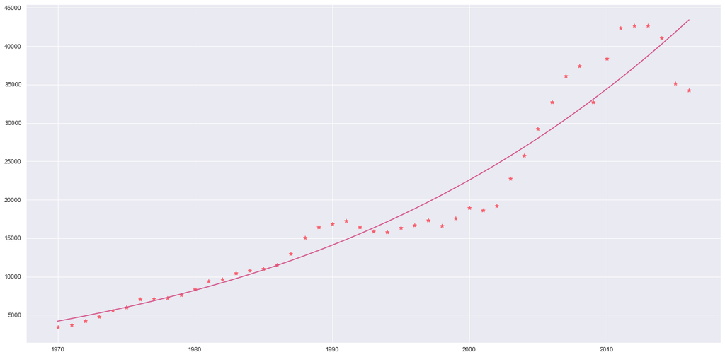

```python
# Now lets plot our data alongwith the regression curve

plt.figure(figsize=(20,10))

plt.scatter(canada_df['year'], canada_df['per capita income (US$)'], color=colors[5], marker='*')
plt.plot(canada_df['year'], polyRig.predict(polyFit.fit_transform(canada_df[['year']])), color=colors[4])

plt.show()
```

```python
# Lets predict the per capita income for the year 2023

y_prediction = polyRig.predict(polyFit.fit_transform([[2023]]))

print(f"Per capita income for the year 2023 will probably be : {y_prediction[0]:.4f}")
```

```
Per capita income for the year 2023 will probably be : 56017.2646
```

```python
# Our probable candidates for fitting are 4th degree and 5th degree polynomials, lets check them one by one.

from sklearn.preprocessing import PolynomialFeatures

polyFit = PolynomialFeatures(degree=5)
X_poly = polyFit.fit_transform(canada_df[['year']])

polyRig = LinearRegression()
polyRig.fit(X_poly, canada_df['per capita income (US$)'])
```

```
LinearRegression()
```

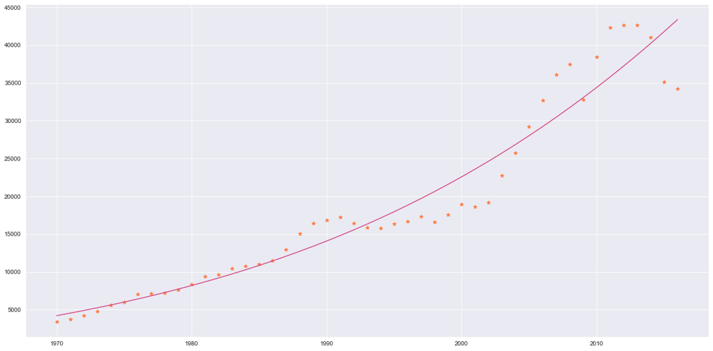

```python
# Now lets plot our data alongwith the regression curve
plt.figure(figsize=(20,10))

plt.scatter(canada_df['year'], canada_df['per capita income (US$)'], marker='*', color=colors[6])
plt.plot(canada_df['year'], polyRig.predict(polyFit.fit_transform(canada_df[['year']])), color=colors[4])

plt.show()
```

```python
# Lets predict the per capita income for the year 2023


y_prediction = polyRig.predict(polyFit.fit_transform([[2023]]))

print(f"Per capita income for the year 2023 will probably be : {y_prediction[0]:.4f}")
```

```
Per capita income for the year 2023 will probably be : 55976.9003
```

We can see that even if there is no notable change in the curvature of the graph, the result of both the predictions are different.

### Prevention of Over and Under-fitting :-

#### 1. Ridge Regression :- L2 Regression

This is also a linear model for regression, so the formula it uses to make predictions is the same as that for Linear Regression.

Prediction formula for Ridge regression is :-

$\hat{y} = w[0]x[0] + w[1]x[1] + w[2]x[2] + ... + w[n]x[n] + b$

↑ Feature!

> 🐎 In Ridge, the coeff $w[i]$ are chosen not only so that they predict well on the training set, but also fit relatively well on the additional testing data. We also want the magnitude of coefficient to be as small as possible (as near to 0 as possible)

Ridge regression shrinks the regression coefficients, so that variables, with minor contribution to the outcome, have their coefficients close to zero. The shrinkage of the coefficients is achieved by penalizing the regression model with a penalty term called L2-norm, which is the sum of the squared coefficients.

Smaller value of a feature's coefficient means that feature will have minimum effect on the predicted output. This constraint is used to implement **regularization**.

Training Score [Ridge Regression] < Training Score [Linear Regression]  
Testing Score [Ridge Regression] > Testing Score [Linear Regression]

$J(a,b) = 1/2m \sum[((a + bx_{obs}) - y_{obs})]^2$ → Cost function of Linear Regression  
$J(a,b) = 1/2m \sum[((a + bx_{obs}) - y_{obs})]^2 + \lambda\sum{b_j^2}$ → Cost function of Ridge Regression

#### 2. Lasso Regression :- L1 Regression

An alternative to Ridge regression for regularizing linear regression model. Lasso regression also restricts the coefficients to be close to zero, but in a slightly different way.

> 🐔 Consequence of L1 is that in this regression some coefficients are exactly 0. $ie$ some features are completely ignored.

Less important features and unnecessary features are ignored to bring out effect from important features.

$J(a,b) = 1/2m \sum[((a + bx_{obs}) - y_{obs})]^2 + \lambda\sum|{b_j}|$ → Cost function of Lasso Regression

- Penalty selectively shrinks some coefficients.
- Can be used for feature selection.
- Slower to converge than Ridge regression.

$\lambda \propto \frac{1}{features}$      OR $features \propto \frac{1}{\lambda}$

#### Lets see regularization of a model using Ridge Regression

```python
# Step 1 : Importing the required libraries and datasets

# We'll use the same boston dataset

from sklearn.linear_model import Ridge
```

```python
boston_df
```

|  | CRIM | ZN | INDUS | CHAS | NOX | RM | AGE | DIS | RAD | TAX | PTRATIO | B | LSTAT | Target |
| --- | --- | --- | --- | --- | --- | --- | --- | --- | --- | --- | --- | --- | --- | --- |
| 0 | 0.00632 | 18.0 | 2.31 | 0.0 | 0.538 | 6.575 | 65.2 | 4.0900 | 1.0 | 296.0 | 15.3 | 396.90 | 4.98 | 24.0 |
| 1 | 0.02731 | 0.0 | 7.07 | 0.0 | 0.469 | 6.421 | 78.9 | 4.9671 | 2.0 | 242.0 | 17.8 | 396.90 | 9.14 | 21.6 |
| 2 | 0.02729 | 0.0 | 7.07 | 0.0 | 0.469 | 7.185 | 61.1 | 4.9671 | 2.0 | 242.0 | 17.8 | 392.83 | 4.03 | 34.7 |
| 3 | 0.03237 | 0.0 | 2.18 | 0.0 | 0.458 | 6.998 | 45.8 | 6.0622 | 3.0 | 222.0 | 18.7 | 394.63 | 2.94 | 33.4 |
| 4 | 0.06905 | 0.0 | 2.18 | 0.0 | 0.458 | 7.147 | 54.2 | 6.0622 | 3.0 | 222.0 | 18.7 | 396.90 | 5.33 | 36.2 |
| ... | ... | ... | ... | ... | ... | ... | ... | ... | ... | ... | ... | ... | ... | ... |
| 501 | 0.06263 | 0.0 | 11.93 | 0.0 | 0.573 | 6.593 | 69.1 | 2.4786 | 1.0 | 273.0 | 21.0 | 391.99 | 9.67 | 22.4 |
| 502 | 0.04527 | 0.0 | 11.93 | 0.0 | 0.573 | 6.120 | 76.7 | 2.2875 | 1.0 | 273.0 | 21.0 | 396.90 | 9.08 | 20.6 |
| 503 | 0.06076 | 0.0 | 11.93 | 0.0 | 0.573 | 6.976 | 91.0 | 2.1675 | 1.0 | 273.0 | 21.0 | 396.90 | 5.64 | 23.9 |
| 504 | 0.10959 | 0.0 | 11.93 | 0.0 | 0.573 | 6.794 | 89.3 | 2.3889 | 1.0 | 273.0 | 21.0 | 393.45 | 6.48 | 22.0 |
| 505 | 0.04741 | 0.0 | 11.93 | 0.0 | 0.573 | 6.030 | 80.8 | 2.5050 | 1.0 | 273.0 | 21.0 | 396.90 | 7.88 | 11.9 |

506 rows × 14 columns

```python
# Step 2 : Dividing our data into training and testing set and creating our model

X = boston_df.drop(['Target'], axis=1)
y = boston_df.Target

print(f'Example Data : \n{X}\n-----------\nLabels : \n{y}')
```

```
Example Data :
        CRIM    ZN  INDUS  CHAS    NOX     RM   AGE     DIS  RAD    TAX  \
0    0.00632  18.0   2.31   0.0  0.538  6.575  65.2  4.0900  1.0  296.0
1    0.02731   0.0   7.07   0.0  0.469  6.421  78.9  4.9671  2.0  242.0
2    0.02729   0.0   7.07   0.0  0.469  7.185  61.1  4.9671  2.0  242.0
3    0.03237   0.0   2.18   0.0  0.458  6.998  45.8  6.0622  3.0  222.0
4    0.06905   0.0   2.18   0.0  0.458  7.147  54.2  6.0622  3.0  222.0
..       ...   ...    ...   ...    ...    ...   ...     ...  ...    ...
501  0.06263   0.0  11.93   0.0  0.573  6.593  69.1  2.4786  1.0  273.0
502  0.04527   0.0  11.93   0.0  0.573  6.120  76.7  2.2875  1.0  273.0
503  0.06076   0.0  11.93   0.0  0.573  6.976  91.0  2.1675  1.0  273.0
504  0.10959   0.0  11.93   0.0  0.573  6.794  89.3  2.3889  1.0  273.0
505  0.04741   0.0  11.93   0.0  0.573  6.030  80.8  2.5050  1.0  273.0

     PTRATIO       B  LSTAT
```

[output cut: 27 more lines]

```python
X_train, X_test, y_train, y_test = train_test_split(X, y, random_state=0, test_size=0.25)
```

```python
ridgeModel = Ridge().fit(X_train, y_train)

print(f"Training set score : {ridgeModel.score(X_train, y_train)*100}\nTesting set score : {ridgeModel.score(X_test, y_test)*100}")
```

```
Training set score : 76.78858330771392
Testing set score : 62.66182204613857
```

#### Effect of alpha ($\lambda$) on the model score

**$\lambda = 10$**

```python
ridgeModel10 = Ridge(alpha=10).fit(X_train, y_train)

print(f"Training set score : {ridgeModel10.score(X_train, y_train)*100}\nTesting set score : {ridgeModel10.score(X_test, y_test)*100}")
```

```
Training set score : 76.23745182677773
Testing set score : 61.327730472069966
```

We can see that underfitting has started, neither the training score nor the testing score is good.

**$\lambda = 1$**

```python
ridgeModel1 = Ridge(alpha=1).fit(X_train, y_train)

print(f"Training set score : {ridgeModel1.score(X_train, y_train)*100}\nTesting set score : {ridgeModel1.score(X_test, y_test)*100}")
```

```
Training set score : 76.78858330771392
Testing set score : 62.66182204613857
```

**$\lambda = 0.1$**

```python
ridgeModel01 = Ridge(alpha=0.1).fit(X_train, y_train)

print(f"Training set score : {ridgeModel01.score(X_train, y_train)*100}\nTesting set score : {ridgeModel01.score(X_test, y_test)*100}")
```

```
Training set score : 76.97119401063664
Testing set score : 63.42855934691842
```

**$\lambda = 0.0001$**

```python
ridgeModel00001 = Ridge(alpha=0.0001).fit(X_train, y_train)

print(f"Training set score : {ridgeModel00001.score(X_train, y_train)*100}\nTesting set score : {ridgeModel00001.score(X_test, y_test)*100}")
```

```
Training set score : 76.9769948804977
Testing set score : 63.546264354434875
```

Not much but the relative accuracy has surely increased. The reason of this low accuracy is probably the size of the dataset, Linear models or any other model require lots and lots of data to create a truly accurate model.

So, let us now use the extended version of the Boston Housing Dataset which can be accessed using the mglearn library.

```python
import mglearn

X, y = mglearn.datasets.load_extended_boston()
```

```python
X_train, X_test, y_train, y_test = train_test_split(X, y, random_state=0)
```

```python
# Lets first check the accuracy of a simple linear model

linReg = LinearRegression().fit(X_train, y_train)

print(f"Training set score : {linReg.score(X_train, y_train)*100}\nTesting set score : {linReg.score(X_test, y_test)*100}")
```

```
Training set score : 95.20519609032729
Testing set score : 60.74721959665881
```

Training score is pretty decent but the testing score straight up sucks!!!

```python
# Let us now use the Ridge Regression Model

ridgeModelExt = Ridge().fit(X_train, y_train)

print(f"Training set score : {ridgeModelExt.score(X_train, y_train)*100}\nTesting set score : {ridgeModelExt.score(X_test, y_test)*100}")
```

```
Training set score : 88.5796658517094
Testing set score : 75.27683481744748
```

**$\lambda = 10$**

```python
ridgeModelExt10 = Ridge(alpha=10).fit(X_train, y_train)

print(f"Training set score : {ridgeModelExt10.score(X_train, y_train)*100}\nTesting set score : {ridgeModelExt10.score(X_test, y_test)*100}")   # Underfitted Model
```

```
Training set score : 78.82787115369615
Testing set score : 63.59411489177311
```

**$\lambda = 1$**

```python
ridgeModelExt1 = Ridge(alpha=1).fit(X_train, y_train)

print(f"Training set score : {ridgeModelExt1.score(X_train, y_train)*100}\nTesting set score : {ridgeModelExt1.score(X_test, y_test)*100}")
```

```
Training set score : 88.5796658517094
Testing set score : 75.27683481744748
```

**$\lambda = 0.1$**

```python
ridgeModelExt01 = Ridge(alpha=0.1).fit(X_train, y_train)

print(f"Training set score : {ridgeModelExt01.score(X_train, y_train)*100}\nTesting set score : {ridgeModelExt01.score(X_test, y_test)*100}")
```

```
Training set score : 92.82273685001994
Testing set score : 77.22067936479662
```

**$\lambda = 0.0001$**

```python
ridgeModelExt00001 = Ridge(alpha=0.0001).fit(X_train, y_train)

print(f"Training set score : {ridgeModelExt00001.score(X_train, y_train)*100}\nTesting set score : {ridgeModelExt00001.score(X_test, y_test)*100}")  # Overlooking various features --- Overfitting
```

```
Training set score : 95.13789921673391
Testing set score : 61.831957815371055
```

#### Lets see regularization of a model using Lasso Regression

```python
from sklearn.linear_model import Lasso
```

```python
lassoModel = Lasso().fit(X_train, y_train)

print(f"Training set score : {lassoModel.score(X_train, y_train)*100}\nTesting set score : {lassoModel.score(X_test, y_test)*100}\nNumber of features used : {np.sum(lassoModel.coef_ != 0)}") # Heavy Underfitting
```

```
Training set score : 29.323768991114598
Testing set score : 20.937503255272272
Number of features used : 4
```

Very less number of features are used, and for the reference there are 104 features in this dataset... ☢️☢️💀💀

$\lambda = 0.01$

```python
lassoModel001 = Lasso(alpha=0.01, max_iter=10000).fit(X_train, y_train)

print(f"Training set score : {lassoModel001.score(X_train, y_train)*100}\nTesting set score : {lassoModel001.score(X_test, y_test)*100}\nNumber of features used : {np.sum(lassoModel001.coef_ != 0)}")
```

```
Training set score : 89.622265110865
Testing set score : 76.56571174549978
Number of features used : 33
```

*max_iter* → Maximum number of iterations taken for the solvers to converge.

$\lambda = 0.0001$

```python
lassoModel00001 = Lasso(alpha=0.0001, max_iter=100000).fit(X_train, y_train)

print(f"Training set score : {lassoModel00001.score(X_train, y_train)*100}\nTesting set score : {lassoModel00001.score(X_test, y_test)*100}\nNumber of features used : {np.sum(lassoModel00001.coef_ != 0)}")   # Overfitting
```

```
Training set score : 95.07158754515463
Testing set score : 64.37467421273729
Number of features used : 96
```

### Elastic Net Regression :

The best of both worlds! Usually, Ridge is the first choice between the two. But we can use both in Elastic Net or EN Regression.

$J(a,b) = 1/2m \sum[((a + bx_{obs}) - y_{obs})]^2 + \lambda\sum|{b_j}| + \lambda\sum{b_j^2}$ → Cost function

Notice both the penalty functions, each correspond to Lasso and Ridge respectively.

### Importance of Feature Selection :

- Reducing the number of features is another way of preventing overfitting.
- For some models fewer features can improve fitting time.
- Identifying most critical features can improve model interpretability.

#### Lets see regularization of a model using Elastic Net Regression

```python
# This time we will be using another dataset called the diabetes dataset

from sklearn.datasets import load_diabetes
from sklearn.linear_model import ElasticNet
from sklearn.metrics import r2_score    # Another error metric

diabetes = load_diabetes()

diabetes
```

[output not shown]

[output cut: 13 more lines]

[output not shown]

```python
diabetes_df = pd.DataFrame(diabetes.data)

diabetes_df
```

|  | 0 | 1 | 2 | 3 | 4 | 5 | 6 | 7 | 8 | 9 |
| --- | --- | --- | --- | --- | --- | --- | --- | --- | --- | --- |
| 0 | 0.038076 | 0.050680 | 0.061696 | 0.021872 | -0.044223 | -0.034821 | -0.043401 | -0.002592 | 0.019908 | -0.017646 |
| 1 | -0.001882 | -0.044642 | -0.051474 | -0.026328 | -0.008449 | -0.019163 | 0.074412 | -0.039493 | -0.068330 | -0.092204 |
| 2 | 0.085299 | 0.050680 | 0.044451 | -0.005671 | -0.045599 | -0.034194 | -0.032356 | -0.002592 | 0.002864 | -0.025930 |
| 3 | -0.089063 | -0.044642 | -0.011595 | -0.036656 | 0.012191 | 0.024991 | -0.036038 | 0.034309 | 0.022692 | -0.009362 |
| 4 | 0.005383 | -0.044642 | -0.036385 | 0.021872 | 0.003935 | 0.015596 | 0.008142 | -0.002592 | -0.031991 | -0.046641 |
| ... | ... | ... | ... | ... | ... | ... | ... | ... | ... | ... |
| 437 | 0.041708 | 0.050680 | 0.019662 | 0.059744 | -0.005697 | -0.002566 | -0.028674 | -0.002592 | 0.031193 | 0.007207 |
| 438 | -0.005515 | 0.050680 | -0.015906 | -0.067642 | 0.049341 | 0.079165 | -0.028674 | 0.034309 | -0.018118 | 0.044485 |
| 439 | 0.041708 | 0.050680 | -0.015906 | 0.017282 | -0.037344 | -0.013840 | -0.024993 | -0.011080 | -0.046879 | 0.015491 |
| 440 | -0.045472 | -0.044642 | 0.039062 | 0.001215 | 0.016318 | 0.015283 | -0.028674 | 0.026560 | 0.044528 | -0.025930 |
| 441 | -0.045472 | -0.044642 | -0.073030 | -0.081414 | 0.083740 | 0.027809 | 0.173816 | -0.039493 | -0.004220 | 0.003064 |

442 rows × 10 columns

```python
X_train, X_test, y_train, y_test = train_test_split(diabetes.data, diabetes.target, random_state=2, test_size=0.25)
```

$\lambda = 1$

```python
ENreg = ElasticNet(alpha=1,l1_ratio=0.9)

ENreg.fit(X_train,y_train)
y_pred = ENreg.predict(X_test)

print(f"R2 Score : {r2_score(y_test,y_pred)*100}")
```

```
R2 Score : 2.5841896057826497
```

$\lambda = 0.1$

```python
ENreg01 = ElasticNet(alpha=0.1,l1_ratio=0.9)

ENreg01.fit(X_train,y_train)
y_pred = ENreg01.predict(X_test)

print(f"R2 Score : {r2_score(y_test,y_pred)*100}")
```

```
R2 Score : 26.47045915740639
```

$\lambda = 0.01$

```python
ENreg001 = ElasticNet(alpha=0.01,l1_ratio=0.9)

ENreg001.fit(X_train,y_train)
y_pred = ENreg001.predict(X_test)

print(f"R2 Score : {r2_score(y_test,y_pred)*100}")
```

```
R2 Score : 43.545036098194025
```

$\lambda = 0.001$

```python
ENreg0001 = ElasticNet(alpha=0.001,l1_ratio=0.9)

ENreg0001.fit(X_train,y_train)
y_pred = ENreg0001.predict(X_test)

print(f"R2 Score : {r2_score(y_test,y_pred)*100}")
```

```
R2 Score : 44.73503374737765
```

### Gradient Descent Method :

This is a method rather algorithm to minimize the cost/loss function.

Gradient descent (GD) is an iterative first-order optimisation algorithm used to find a local minimum/maximum of a given function. This method is commonly used in machine learning (ML) and deep learning(DL) to minimise a cost/loss function.

In this method, we start with a cost function $J(\beta)$, and reach the minimum value by decreasing the value of $\beta$.

But in this case if the number of features are more then the surface becomes a hyperplane (higher order) and the minimum cannot be found so easily.

$\triangledown{J(\beta_0, \beta_1, ..., \beta_n)} = <\frac{\delta{J}}{\delta{\beta_0}} + \frac{\delta{J}}{\delta{\beta_1}} + ... + \frac{\delta{J}}{\delta{\beta_n}}>$

#### Let us now train our linear model and minimize its cost using Gradient Descent Method

```python
# We'll again use the extended Boston dataset for training and testing this model

from sklearn.linear_model import SGDRegressor

X, y = mglearn.datasets.load_extended_boston()
```

```python
X_train, X_test, y_train, y_test = train_test_split(X, y, random_state=0, test_size=0.25)
```

$\lambda = 0.1$

```python
sgdReg01 = SGDRegressor(loss='squared_loss', alpha=0.1, penalty='l2').fit(X_train, y_train)

print(f"Training set score : {sgdReg01.score(X_train, y_train)*100}\nTesting set score: {sgdReg01.score(X_test, y_test)*100}")
```

```
Training set score : 69.08904394742383
Testing set score: 53.40344526059147
```

$\lambda = 0.01$

```python
sgdReg001 = SGDRegressor(loss='squared_loss', alpha=0.01, penalty='l2').fit(X_train, y_train)

print(f"Training set score : {sgdReg001.score(X_train, y_train)*100}\nTesting set score: {sgdReg001.score(X_test, y_test)*100}")
```

```
Training set score : 80.33140713726206
Testing set score: 66.02287888127707
```

$\lambda = 0.001$

```python
sgdReg0001 = SGDRegressor(loss='squared_loss', alpha=0.001, penalty='l2').fit(X_train, y_train)

print(f"Training set score : {sgdReg0001.score(X_train, y_train)*100}\nTesting set score: {sgdReg0001.score(X_test, y_test)*100}")
```

```
Training set score : 79.84414227791838
Testing set score: 65.1523205034356
```

### Logistic Regression :

Linear models are also extensively used for classification. Classification by logistic regression is pretty simple and straightforward.

[figure not shown]

Logistic Function is of the form :-

$f(x) = \frac{1}{1 + e^{-x}}$

$x$ is then replaced with the linear regression curve for the data and the classifier function alongwith the decision boundary is obtained.

$f(x) = \frac{1}{1 + e^{-(a + bx)}}$, where $a + bx$ is the regression curve.

#### Lets now create our own logistic regression model.

```python
# As always we will first import our libraries and datasets

from sklearn.linear_model import LogisticRegression

insurance_df = pd.read_csv('../Assets/insurance_data.csv')

insurance_df
```

|  | age | bought_insurance |
| --- | --- | --- |
| 0 | 22 | 0 |
| 1 | 25 | 0 |
| 2 | 47 | 1 |
| 3 | 52 | 0 |
| 4 | 46 | 1 |
| 5 | 56 | 1 |
| 6 | 55 | 0 |
| 7 | 60 | 1 |
| 8 | 62 | 1 |
| 9 | 61 | 1 |
| 10 | 18 | 0 |
| 11 | 28 | 0 |
| 12 | 27 | 0 |
| 13 | 29 | 0 |
| 14 | 49 | 1 |
| 15 | 55 | 1 |
| 16 | 25 | 1 |
| 17 | 58 | 1 |
| 18 | 19 | 0 |
| 19 | 18 | 0 |
| 20 | 21 | 0 |
| 21 | 26 | 0 |
| 22 | 40 | 1 |
| 23 | 45 | 1 |
| 24 | 50 | 1 |
| 25 | 54 | 1 |
| 26 | 23 | 0 |

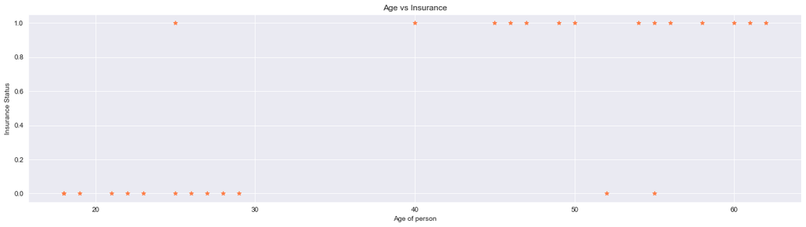

```python
plt.figure(figsize=(20,5))

plt.scatter(insurance_df['age'], insurance_df['bought_insurance'], color=colors[6], marker='*')

plt.xlabel("Age of person")
plt.ylabel('Insurance Status')
plt.title('Age vs Insurance')

plt.show()
```

```python
insReg = LinearRegression()
insReg.fit(insurance_df[['age']], insurance_df['bought_insurance'])

print(f'Coefficient : {insReg.coef_[0]}\nIntercept : {insReg.intercept_}')
```

```
Coefficient : 0.023683938359706273
Intercept : -0.4209443697498303
```

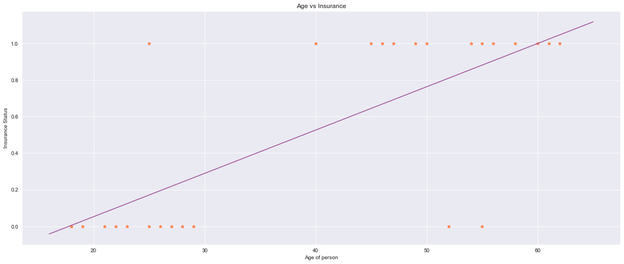

```python
x = np.linspace(16, 65, 2)
y = insReg.coef_*x + insReg.intercept_


plt.figure(figsize=(20, 8))

plt.scatter(insurance_df['age'], insurance_df['bought_insurance'], color=colors[6], marker='*')
plt.plot(x, y, color=colors[3])

plt.xlabel("Age of person")
plt.ylabel('Insurance Status')
plt.title('Age vs Insurance')

plt.show()
```

```python
X_train, X_test, y_train, y_test = train_test_split(insurance_df[['age']], insurance_df['bought_insurance'], test_size=0.2, random_state=0)
```

```python
logReg = LogisticRegression().fit(X_train, y_train)

print(f'Coefficient : {logReg.coef_[0]}\nIntercept : {logReg.intercept_[0]}')
```

```
Coefficient : [0.11216016]
Intercept : -4.609606842692203
```

```python
# Lets check the accuracy of our model

print(f'Model Accuracy : {logReg.score(X_test, y_test)*100}')
```

```
Model Accuracy : 100.0
```

Daammmmnnn!!! 🦫🦫

```python
# Lets predict some values now

age = 43

y_prediction = logReg.predict([[age]])

print(f'Insurance status for person aged {age} : {y_prediction}')
```

```
Insurance status for person aged 43 : [1]
```

# Classification Error Metric :

Let us assume a dataset which classifies the patients whether they have Leukemia or not.

**Training Data** : 1% patients are positive, 99% are healthy.

**Measure Accuracy** : Total % predictions that are correct.

- Build a simple model that will predict "healthy".
- Accuracy will be 99%.

[figure not shown]

**Recall** : Number of correct results divided by the number of results that should have been returned. (The fraction that we correctly predict +ve).

**Precision** : Of all the records we predicted +ve, what are actually +ve.

**Specificity** : The metric that evaluates a model's ability to predict true -ve of each category.

$F_1 = \frac{Precision * Recall}{Precision + Recall}$ → Classification model score metric.

### Naive Bayes Model :

#### Revisiting Conditional Probability :

Probability of an event $X$ happening is = $P(X)$

Probability of an event $Y$ happening is = $P(Y)$

these, are single event probabilities. Now let us see joint event probabilities...

Probability of an event $X$ `and` $Y$ happening is = $P(X\cap{Y})$, this is the probability of events $X$ and $Y$ happening simultaneously.

P(what we want to know | what we know) = P(what we want to know) / P(what we know)

**Explanation** : We want to find the probability of a certain task given that some other task has already occurred.

$P(Y|X) * P(X) = P(X|Y)* P(Y)$  
$P(Y|X) = \frac{P(X|Y) * P(Y)}{P(X)}$

#### Training Naive Bayes :-

For each class $C$, calculate probability given features ($X$) $\implies$ $P(C|X) = P(X|C) * P(C)$, where $C$ is the class and $X$ is a feature.

Features :

- $X_1 \cap X_2 \cap X_3 = C_1$
- $X_2 \cap X_3 \cap ... \cap X_n = C_x$
- $X_5 \cap X_8 \cap... \cap X_q = C_y$
- $X_8 \cap X_7 \cap ... \cap X_p = C_z$

$C$ is what we want to know, $X$ is what we we already know.

##### Why Naive?

We assume that each feature is mutually exclusive, this is our *naive* assumption.

$\therefore$    $P(C|X) = P(X_1 \cap X_2 \cap ... \cap X_n | C) * P(C)$  
$\implies$ $P(C|X) = P(X_1|C) *P(X_2 | C) * ... * P(X_n | C) * P(C)$

End result : $\implies$ $P(C|X) = \prod P(X_i | C) * P(C)$

#### Lets now train our own naive bayes classifier model

```python
# Step 1 : As always we will start by importing the required libraries and datasets

from sklearn.naive_bayes import GaussianNB

titanic_df = pd.read_csv('../Assets/titanic.csv')

titanic_df.head()
```

|  | PassengerId | Name | Pclass | Sex | Age | SibSp | Parch | Ticket | Fare | Cabin | Embarked | Survived |
| --- | --- | --- | --- | --- | --- | --- | --- | --- | --- | --- | --- | --- |
| 0 | 1 | Braund, Mr. Owen Harris | 3 | male | 22.0 | 1 | 0 | A/5 21171 | 7.2500 | NaN | S | 0 |
| 1 | 2 | Cumings, Mrs. John Bradley (Florence Briggs Th... | 1 | female | 38.0 | 1 | 0 | PC 17599 | 71.2833 | C85 | C | 1 |
| 2 | 3 | Heikkinen, Miss. Laina | 3 | female | 26.0 | 0 | 0 | STON/O2. 3101282 | 7.9250 | NaN | S | 1 |
| 3 | 4 | Futrelle, Mrs. Jacques Heath (Lily May Peel) | 1 | female | 35.0 | 1 | 0 | 113803 | 53.1000 | C123 | S | 1 |
| 4 | 5 | Allen, Mr. William Henry | 3 | male | 35.0 | 0 | 0 | 373450 | 8.0500 | NaN | S | 0 |

Most of the features in this dataset are non numerical, so there is no point in visualizing this data as we won't get any specific inference.

```python
# As we can see most of the columns in the dataset are non numerical and will not help in training our model, so let us exclude these columns from our dataset.

X = titanic_df[[ 'Pclass', 'Sex', 'Age', 'Fare']]
y = titanic_df['Survived']
```

```python
# In our dataset, gender is a very important feature so now lets convert this non numeric data to a categorical one and add to out dataset.

dummies = pd.get_dummies(X.Sex)

dummies.head(n=10)
```

|  | female | male |
| --- | --- | --- |
| 0 | 0 | 1 |
| 1 | 1 | 0 |
| 2 | 1 | 0 |
| 3 | 1 | 0 |
| 4 | 0 | 1 |
| 5 | 0 | 1 |
| 6 | 0 | 1 |
| 7 | 0 | 1 |
| 8 | 1 | 0 |
| 9 | 1 | 0 |

```python
# Now lets add this gender data to our input dataset

X = pd.concat([X, dummies], axis=1)
X.drop('Sex', axis=1, inplace=True)

X.head()
```

|  | Pclass | Age | Fare | female | male |
| --- | --- | --- | --- | --- | --- |
| 0 | 3 | 22.0 | 7.2500 | 0 | 1 |
| 1 | 1 | 38.0 | 71.2833 | 1 | 0 |
| 2 | 3 | 26.0 | 7.9250 | 1 | 0 |
| 3 | 1 | 35.0 | 53.1000 | 1 | 0 |
| 4 | 3 | 35.0 | 8.0500 | 0 | 1 |

```python
# The preliminary examination of the dataset suggests that there are NaN values present, so lets find them and replace with some other values

X.columns[X.isna().any()]
```

```
Index(['Age'], dtype='object')
```

```python
X.Age.head(n=10)
```

```
0    22.0
1    38.0
2    26.0
3    35.0
4    35.0
5     NaN
6    54.0
7     2.0
8    27.0
9    14.0
Name: Age, dtype: float64
```

```python
import math
```

```python
# Lets see which rows in the dataset are NaN

X.loc[X['Age'] == math.nan]     # Sad 🥲 We'll just update these values with the mean age
```

|  | Pclass | Age | Fare | female | male |
| --- | --- | --- | --- | --- | --- |

```python
X.Age = X.Age.fillna(math.ceil(X.Age.mean()))

X.head(n=10)
```

|  | Pclass | Age | Fare | female | male |
| --- | --- | --- | --- | --- | --- |
| 0 | 3 | 22.0 | 7.2500 | 0 | 1 |
| 1 | 1 | 38.0 | 71.2833 | 1 | 0 |
| 2 | 3 | 26.0 | 7.9250 | 1 | 0 |
| 3 | 1 | 35.0 | 53.1000 | 1 | 0 |
| 4 | 3 | 35.0 | 8.0500 | 0 | 1 |
| 5 | 3 | 30.0 | 8.4583 | 0 | 1 |
| 6 | 1 | 54.0 | 51.8625 | 0 | 1 |
| 7 | 3 | 2.0 | 21.0750 | 0 | 1 |
| 8 | 3 | 27.0 | 11.1333 | 1 | 0 |
| 9 | 2 | 14.0 | 30.0708 | 1 | 0 |

```python
# Now lets train our model, but first we'll have to split our data

X_train, X_test, y_train, y_test = train_test_split(X, y, test_size=0.25)
```

```python
NBModel = GaussianNB()

NBModel.fit(X_train, y_train)
```

```
GaussianNB()
```

```python
print(f"Model Accuracy : {NBModel.score(X_test, y_test) * 100}")
```

```
Model Accuracy : 76.23318385650224
```

So - So accurate

```python
X_test.head()
```

|  | Pclass | Age | Fare | female | male |
| --- | --- | --- | --- | --- | --- |
| 1 | 1 | 38.0 | 71.2833 | 1 | 0 |
| 691 | 3 | 4.0 | 13.4167 | 1 | 0 |
| 500 | 3 | 17.0 | 8.6625 | 0 | 1 |
| 776 | 3 | 30.0 | 7.7500 | 0 | 1 |
| 525 | 3 | 40.5 | 7.7500 | 0 | 1 |

```python
y_test.head()
```

```
1      1
691    1
500    0
776    0
525    0
Name: Survived, dtype: int64
```

```python
NBModel.predict(X_test.head())
```

```
array([1, 1, 0, 0, 0], dtype=int64)
```

```python
# In this algorithm we can also check the probability of every testcase; probability of whether the person survived or not.

NBModel.predict_proba(X_test.head())

# Note ☢️ : this method returns the probability of the person not surviving.
```

```
array([[0.00189748, 0.99810252],
       [0.02335757, 0.97664243],
       [0.98973869, 0.01026131],
       [0.99156986, 0.00843014],
       [0.99172627, 0.00827373]])
```

### Kernelized Support Vector Machines :

- SVMs are an extension to the linear classification models that allow complex data based on hyperplanes to be classified easily.
- A linear model can distinguish between 2 classes only.

#### Classification With SVMs :-

1. Find the best fit line that separates the two lines
2. Include the largest boundary possible.

[figure not shown]

We want to find a line such that, it leaves as mush as space possible from both the boundaries. We want to place the line in the center of the two decision boundaries.

[figure not shown]

#### First we will explore the drawbacks of simple SVM and the need of kernelisation.

```python
from mglearn import make_blobs
```

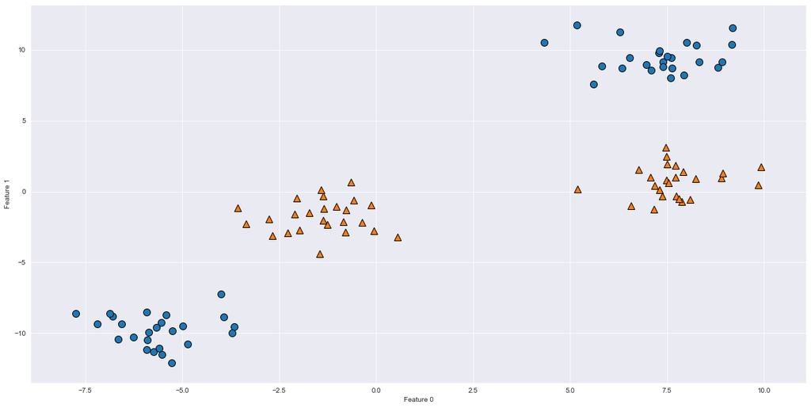

```python
X, y = make_blobs.make_blobs(centers=4, random_state=8)
y = y % 2

figure = plt.figure(figsize=(20,10))

mglearn.discrete_scatter(X[:, 0], X[:, 1], y)

plt.xlabel("Feature 0")
plt.ylabel("Feature 1")

plt.show()
```

Even though there are only 2 features, multi-clustering is occurring, which means that a single line cannot be used to classify these data points.

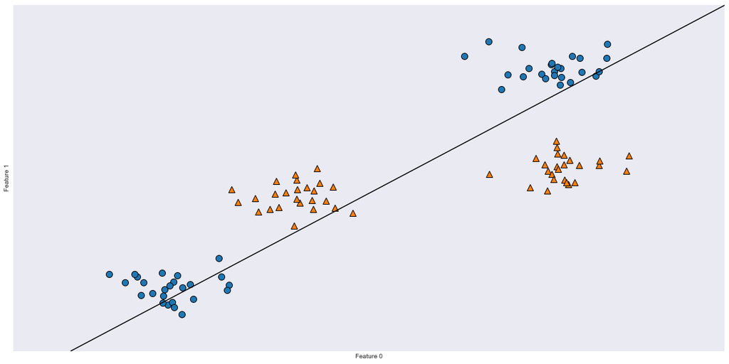

```python
# First we will import the necessary libraries and train the model directly, as this is a synthetic dataset

from sklearn.svm import LinearSVC
linear_svm = LinearSVC().fit(X, y)

figure = plt.figure(figsize=(20,10))

mglearn.plots.plot_2d_separator(linear_svm, X)
mglearn.discrete_scatter(X[:, 0], X[:, 1], y)

plt.xlabel("Feature 0")
plt.ylabel("Feature 1")
```

As we can see the model is unable to classify the clustered data points, therefore now we will use kernelisation.

**Kernelisation** : The use of higher dimensions to convert non-linear data to linear data.

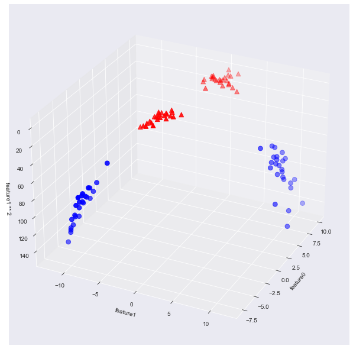

```python
X_new = np.hstack([X, X[:, 1:] ** 2])
from mpl_toolkits.mplot3d import Axes3D, axes3d
figure = plt.figure(figsize=(20,8))

# visualize in 3D

ax = Axes3D(figure, elev=-152, azim=-26)

# plot first all the points with y == 0, then all with y == 1
mask = y == 0

ax.scatter(X_new[mask, 0], X_new[mask, 1], X_new[mask, 2], c='b',
cmap=mglearn.cm2, s=60)
ax.scatter(X_new[~mask, 0], X_new[~mask, 1], X_new[~mask, 2], c='r', marker='^',
cmap=mglearn.cm2, s=60)

ax.set_xlabel("feature0")
ax.set_ylabel("feature1")
ax.set_zlabel("feature1 ** 2")
```

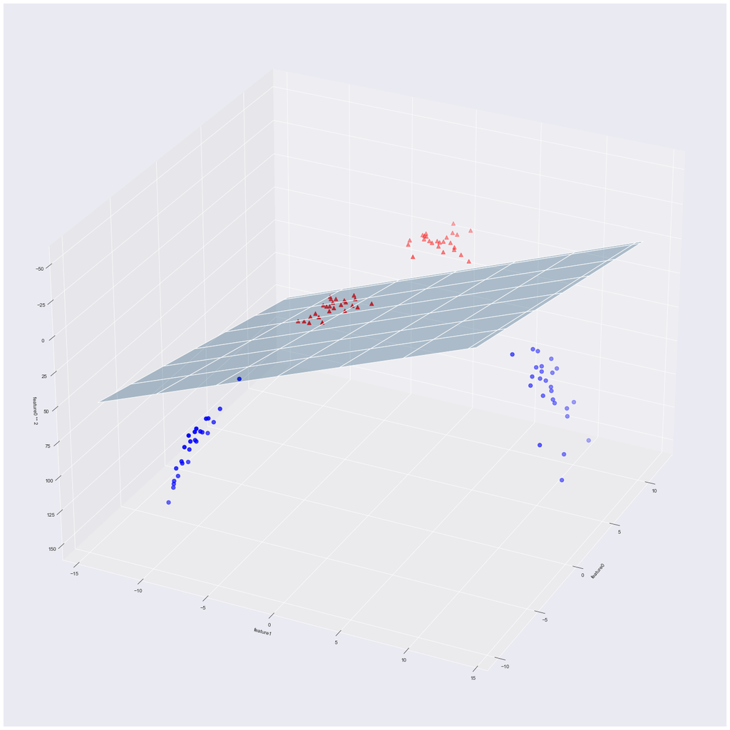

```python
linear_svm_3d = LinearSVC().fit(X_new, y)
coef, intercept = linear_svm_3d.coef_.ravel(), linear_svm_3d.intercept_

# show linear decision boundary

figure = plt.figure(figsize=(20,20))
ax = Axes3D(figure, elev=-152, azim=-26)
xx = np.linspace(X_new[:, 0].min() - 2, X_new[:, 0].max() + 2, 50)
yy = np.linspace(X_new[:, 1].min() - 2, X_new[:, 1].max() + 2, 50)
XX, YY = np.meshgrid(xx, yy)

ZZ = (coef[0] * XX + coef[1] * YY + intercept) / -coef[2]
ax.plot_surface(XX, YY, ZZ, rstride=8, cstride=8, alpha=0.3)
ax.scatter(X_new[mask, 0], X_new[mask, 1], X_new[mask, 2], c='b',
cmap=mglearn.cm2, s=60)
ax.scatter(X_new[~mask, 0], X_new[~mask, 1], X_new[~mask, 2], c='r', marker='^',
cmap=mglearn.cm2, s=60)

ax.set_xlabel("feature0")
ax.set_ylabel("feature1")
ax.set_zlabel("feature0 ** 2")

# Note ☢️ : this code is just for visualization of data and better understanding of this model, the explanation and use of this module is beyond the scope of this course...
```

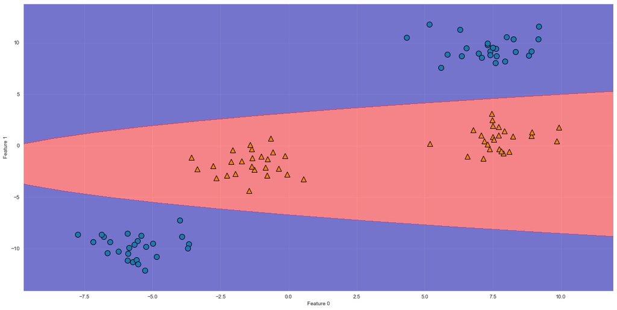

```python
ZZ = YY ** 2

figure = plt.figure(figsize=(20,10))

dec = linear_svm_3d.decision_function(np.c_[XX.ravel(), YY.ravel(), ZZ.ravel()])

plt.contourf(XX, YY, dec.reshape(XX.shape), levels=[dec.min(), 0, dec.max()], cmap=mglearn.cm2, alpha=0.5)
mglearn.discrete_scatter(X[:, 0], X[:, 1], y)

plt.xlabel("Feature 0")
plt.ylabel("Feature 1")

# Contour plot of the 3D data, or the reverse kernalization of the dataset
```

```python
# For beginners, now that we have seen the working of SVM and the importance of kernelization, let us now train this model on a simpler dataset.

# Step 1 : Importing the necessary libraries and datasets

from sklearn.datasets import load_iris
from sklearn.svm import SVC

iris = load_iris()

iris.DESCR
```

```
'.. _iris_dataset:\n\nIris plants dataset\n--------------------\n\n**Data Set Characteristics:**\n\n    :Number of Instances: 150 (50 in each of three classes)\n    :Number of Attributes: 4 numeric, predictive attributes and the class\n    :Attribute Information:\n        - sepal length in cm\n     …
```

```python
iris_df = pd.DataFrame(iris.data, columns=iris.feature_names)
iris_df['target'] = pd.DataFrame(iris.target)

iris_df
```

|  | sepal length (cm) | sepal width (cm) | petal length (cm) | petal width (cm) | target |
| --- | --- | --- | --- | --- | --- |
| 0 | 5.1 | 3.5 | 1.4 | 0.2 | 0 |
| 1 | 4.9 | 3.0 | 1.4 | 0.2 | 0 |
| 2 | 4.7 | 3.2 | 1.3 | 0.2 | 0 |
| 3 | 4.6 | 3.1 | 1.5 | 0.2 | 0 |
| 4 | 5.0 | 3.6 | 1.4 | 0.2 | 0 |
| ... | ... | ... | ... | ... | ... |
| 145 | 6.7 | 3.0 | 5.2 | 2.3 | 2 |
| 146 | 6.3 | 2.5 | 5.0 | 1.9 | 2 |
| 147 | 6.5 | 3.0 | 5.2 | 2.0 | 2 |
| 148 | 6.2 | 3.4 | 5.4 | 2.3 | 2 |
| 149 | 5.9 | 3.0 | 5.1 | 1.8 | 2 |

150 rows × 5 columns

```python
iris_df['Target Names'] = iris_df.target.apply(lambda x: iris.target_names[x])

iris_df
```

|  | sepal length (cm) | sepal width (cm) | petal length (cm) | petal width (cm) | target | Target Names |
| --- | --- | --- | --- | --- | --- | --- |
| 0 | 5.1 | 3.5 | 1.4 | 0.2 | 0 | setosa |
| 1 | 4.9 | 3.0 | 1.4 | 0.2 | 0 | setosa |
| 2 | 4.7 | 3.2 | 1.3 | 0.2 | 0 | setosa |
| 3 | 4.6 | 3.1 | 1.5 | 0.2 | 0 | setosa |
| 4 | 5.0 | 3.6 | 1.4 | 0.2 | 0 | setosa |
| ... | ... | ... | ... | ... | ... | ... |
| 145 | 6.7 | 3.0 | 5.2 | 2.3 | 2 | virginica |
| 146 | 6.3 | 2.5 | 5.0 | 1.9 | 2 | virginica |
| 147 | 6.5 | 3.0 | 5.2 | 2.0 | 2 | virginica |
| 148 | 6.2 | 3.4 | 5.4 | 2.3 | 2 | virginica |
| 149 | 5.9 | 3.0 | 5.1 | 1.8 | 2 | virginica |

150 rows × 6 columns

```python
# In yesterdays session we have already visualized this dataset so we'll not be doing this again... So, instead we will split the data for our model creation

X = iris_df[['sepal length (cm)', 'sepal width (cm)', 'petal length (cm)' , 'petal width (cm)']]
y = iris_df['target']
```

```python
X_train, X_test, y_train, y_test = train_test_split(X, y, test_size=0.25)
```

```python
SVMModel = SVC()    # This object also has attributes like gamma,  c, max_iter, kernel etc. that are used to control the degree of regularization.

SVMModel.fit(X_train, y_train)
```

```
SVC()
```

```python
print(f"Model Accuracy : {SVMModel.score(X_test, y_test) * 100}")
```

```
Model Accuracy : 100.0
```

Daaammmmnnnn!!! 😲😲😲

### Summary :

In this session we studied various other supervised learning models both theoretically and practically.

## Hope you enjoyed the session 🙏👋